# Campaign events and vote intention

What 40dB’s daily tracking poll tells us about the first week of the 29-N campaign

Authors

Jordi Muñoz

Claude

Published

20 November 2026

Versió en català · Versión en castellano

## Summary

The first week of the campaign for Spain’s 29 November general election did little to move vote intention. Most of the events that dominated the news, such as the general strike over housing, the police charges against protesters, the PSOE manifesto or the news that Abascal’s wife had received a heating subsidy for vulnerable families, leave no visible trace in 40dB’s daily polls.

The exception is 13 November, the day the campaign officially began. That day Vox presented its manifesto, Santiago Abascal cancelled an interview with the YouTuber Jordi Wild at the last minute, and laSexta broadcast the first debate. Among respondents interviewed in the following days, Vox’s vote intention is about 3.9 points lower than among those interviewed in the preceding days, and the share who see Abascal as the best prime minister falls by about 4.5 points. Part of the loss goes back to the PP, which wins back some of its 2023 voters who had moved to Vox, and the PSOE also gains ground, although neither gain is as robust as the fall for Vox. The fall in Vox support appears sharper among young men, although that estimate is imprecise.

We cannot tell which of the 13 November events caused the shift, because they all happened on the same day. The daily polls only detect large changes, of four or five points; smaller effects go unnoticed. Details of the data, the method and all the checks are in the technical annex.

## 1 What happened in the first week of the campaign

News coverage tends to treat every campaign day as decisive: a debate, a gaffe or a cancelled interview is read as a turning point. Political science has traditionally been more sceptical. The prevailing view, as summarised by Shaw (1999), is that campaign events rarely have strong effects, because most voters pay little attention, decide on the basis of partisan cues and the state of the economy, and receive balanced information from rival campaigns. Shaw’s own analysis of US presidential elections from 1952 to 1992 qualifies this view: some events, such as debates and conventions, produced significant and fairly durable shifts, while most had negligible or short-lived effects, and analysing them all together hides the ones that matter. The question, then, is which events in this campaign, if any, moved voters.

### 1.1 A stable campaign

Every day 40dB interviews about 500 new people for *El País* and Cadena SER (40dB 2026b). On 17 November *El País* published its vote estimate under the headline [“Vox se frena y cede terreno al PP”](https://elpais.com/espana/elecciones-generales/2026-11-17/vox-se-frena-y-cede-terreno-al-pp.html) (“Vox stalls and loses ground to the PP”) (El País 2026). Here we work with the individual survey responses: by comparing those given on successive days, we can see whether opinion moves after each event. Figure 1 shows vote intention for the main parties in each daily sample, from the pre-election survey of 2–4 November to 19 November.

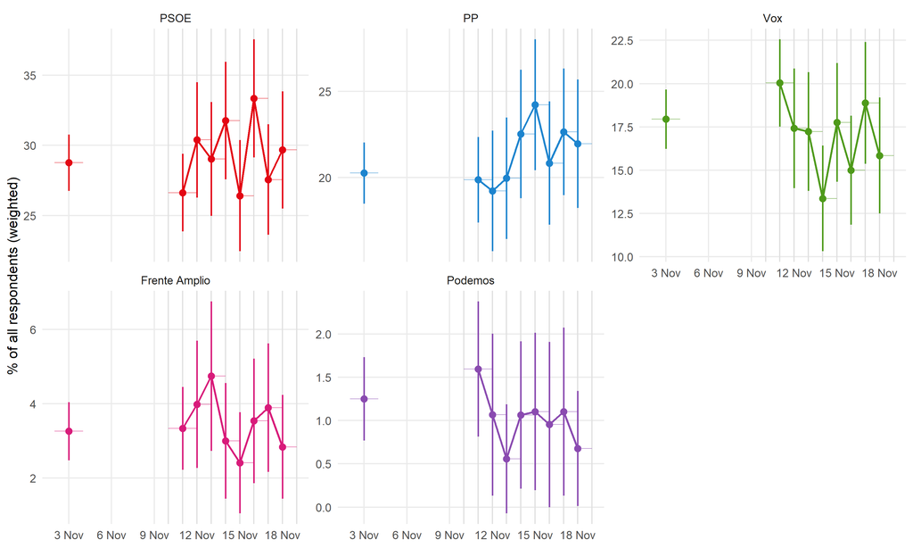

Figure 1: Direct vote intention (percentage of all respondents). Each point is a separate sample; the vertical line through each point shows the margin of error and the horizontal line the days on which interviews took place. Grey vertical lines mark days with relevant events.

The lines move, but most of that movement is noise: with 500 interviews, an estimate of 20% has a margin of error of about 3.5 points either way, and one of 30% about 4 points. Frente Amplio and Podemos stay within that margin all week. The clearest movement is the fall in Vox support from 14 November: it reaches a low of 13.4% on 14–15 November and stays below its 10–12 November level from then on, although on 17–18 November it climbs back to 18.9%, close to where it started, before dropping again to 15.8% on 18–19 November. The PP rises from 19.9% on 10–12 November to 24.2% on 15–16 November, falls back to 20.8% on 16–17 November and stands at 22.7% and 22.0% in the next two samples. The PSOE moves up and down from one day to the next and reaches its highest figure, 33.4%, on 16–17 November.

### 1.2 On 13 November, Vox loses ground and the PP wins voters back

The campaign officially started on 13 November. Vox presented a manifesto centred on deporting migrants and “national priority” in access to housing. Abascal cancelled his scheduled interview with Jordi Wild a few hours before recording, while Sánchez, Feijóo and Colau did take part; the decision was criticised even by voices close to Vox. In the evening, laSexta broadcast the economic debate between spokespeople for the four main parties.

Figure 2 compares the 1,000 people interviewed between 10 and 12 November with the 2,500 interviewed between 14 and 19 November. Vox’s vote intention falls from 20.0% to 16.2%, and the share who see Abascal as the best prime minister from 21.1% to 16.6%. The PP rises from 19.9% to 22.4%, and Feijóo as best prime minister from 21.0% to 22.8%. The fall for Vox and Abascal is the clearest result in the data, and it holds under every alternative way of doing the calculation that we tried, although once we correct for the many comparisons we make it is no longer conclusive on its own. The PP’s gain is less certain: it falls just short of significance in the main specification (p = 0.074) and is significant in only 2 of the 8 specifications. The same is true of the PSOE, which rises from 26.6% to 29.8% (p = 0.071; significant in 2 specifications); Sánchez’s rise as best prime minister is within the margin of error.

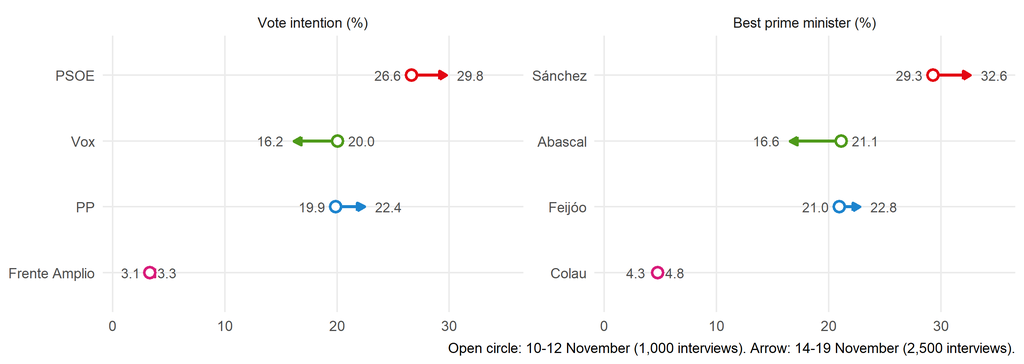

Figure 2: Vote intention and preferred prime minister before and after 13 November (weighted percentages).

Who moved? Among those who say they voted PP in 2023, the share who would vote PP again rises from 67% to 76%, and the share who now back Vox falls by about 7 points. Those who voted Vox in 2023 remain just as loyal. What we see, then, is PP voters who had drifted to Vox returning to the PP, not Vox losing its core.

The fall appears steeper among men aged 18 to 34: Vox’s vote intention in this group drops from 30.3% to 21.9%. This is what we would expect if cancelling the Jordi Wild interview, whose audience is mostly young and male, had hurt Abascal. The difference, however, is not statistically significant: it rests on only 103 interviews before 13 November and 250 after, and should be read with caution.

We cannot attribute the change to a single event. The campaign launch, the Vox manifesto, the cancelled interview and the laSexta debate all fell on the same day, and the data cannot separate them. Moreover, the 10–12 November sample already showed Vox slightly higher than the early-November survey; part of the fall may simply be a return to normal. Even allowing for this, the fall in Vox support remains, although it is smaller (about 2.5 points).

### 1.3 The general strike and the police charges do not move the vote

The general strike over housing on 11 November, the police charges against protesters and Sánchez’s backing for the Interior Minister, Fernando Grande-Marlaska, the following day could have pushed left-wing voters from the PSOE towards Frente Amplio or Podemos. We do not see this: among 2023 PSOE and Sumar voters, support for Frente Amplio and Podemos barely changes (less than one point) and the PSOE does not lose ground. Here the only possible comparison is with the 2–4 November survey, conducted a week earlier with other events in between, so the conclusion is weaker. A small effect, of one or two points, would go undetected.

### 1.4 Hernani and the Canary Islands: impossible to separate from 13 November

On 14 November a group of people attacked a PP information stand in Hernani, and that weekend saw a record number of migrant boat arrivals in the Canary Islands. On 15–19 November the PP is about 2.8 points higher than before. The difference is significant in the main specification (p = 0.037), but not once we correct for multiple comparisons, and it cannot be separated from the one that had already begun on 13 November, because the comparison group was interviewed up to that day. Nor can we check whether the effect is larger in the Basque Country or the Canary Islands, because a single daily sample contains at most 34 interviews from each of those regions.

### 1.5 15 November: the PSOE manifesto

On 15 November the PSOE presented its manifesto and Sánchez called Abascal a racist. The 1,500 people interviewed on 16–19 November back the PSOE about 2.0 points more, and Vox about 2.1 points less, than those interviewed up to 14 November. Both changes go in the expected direction, but they rest on only 3 daily samples and are within the margin of error, even before correcting for multiple comparisons. The comparison group also includes the days before 13 November, so these differences carry the shift that began that day.

### 1.6 16 and 17 November: the Telecinco interview and Abascal’s heating subsidy

On 16 November Lula visited Moncloa, Frente Amplio presented its manifesto and, in the evening, Sánchez gave a tense interview on Telecinco about the Ceuta crisis. On 17 November the government approved a pay rise for public employees and an increase in the minimum wage, and it emerged that Abascal’s wife had received a heating subsidy for vulnerable families, which Abascal defended with a crude attack on Sánchez’s friends. None of these events leaves a detectable trace. After 16 November the PSOE changes by −0.3 points (p = 0.851) and Vox by −0.2 points (p = 0.891). After 17 November Vox changes by −1.6 points (p = 0.373) and Abascal as best prime minister by −2.1 points (p = 0.259): the direction the subsidy story would lead us to expect, but within the margin of error. This last comparison rests on a single daily sample (18–19 November), which can only detect changes of about 5 points.

### 1.7 How to read these results

The coming days of tracking will make it possible to assess 18 November, with Feijóo’s interview on the podcast *El sentido de la birra* and Sánchez’s on Antena 3, and 19 November, the day of the Sánchez–Feijóo head-to-head debate. A SocioMétrica poll for *El Español* found that 64% thought Feijóo had won the debate and 32% Sánchez. On the same day *El Mundo* published an interview with Puigdemont about his negotiations with the PSOE, and a police report attributed the mass entry into Ceuta to advance planning. These three events cannot be separated. We will also see whether the fall in Vox support holds or reverses.

## 2 Technical annex

This section covers the data, the design, the diagnostic tests and the detailed estimates. The whole analysis can be reproduced with `Rscript run_all.R` from the project root, and the full tables are in `output/tables/`.

### 2.1 Data

40dB publishes the tracking as cumulative files (40dB 2026b). The day-2 file contains the 1,000 interviews conducted on 10–12 November and 500 more from 12–13 November. Days 3 and 4 each add 500 interviews, and from day 5 the window rolls: the newest block enters and the oldest leaves. Because the identifier is renumbered and the weights recomputed in every file, we rebuilt the sample of unique interviews by matching each record’s full response profile and position. Each file turns out to be exactly the previous one, minus the oldest blocks, with the new interviews appended at the end. The result is 4,500 unique interviews in 8 fieldwork blocks (Figure 3). We add 40dB’s first pre-election survey (2–4 November, 2,000 interviews), which shares the vote questions with the tracking and serves as a pre-campaign reference (40dB 2026a). All the data can be downloaded from the *El País* website: [pre-election survey](https://ep00.epimg.net/infografias/encuestas40db/2026/11-preelectoral/2026_11_preelectoral_descargables.zip), [day 2](https://ep00.epimg.net/infografias/encuestas40db/2026/11-tracking-electoral/40dB_tracking_dia02.zip), [day 3](https://ep00.epimg.net/infografias/encuestas40db/2026/11-tracking-electoral/40dB_tracking_dia03.zip), [day 4](https://ep00.epimg.net/infografias/encuestas40db/2026/11-tracking-electoral/40dB_tracking_dia04.zip), [day 5](https://ep00.epimg.net/infografias/encuestas40db/2026/11-tracking-electoral/40dB_tracking_dia05.zip), [day 6](https://ep00.epimg.net/infografias/encuestas40db/2026/11-tracking-electoral/40dB_tracking_dia06.zip), [day 7](https://ep00.epimg.net/infografias/encuestas40db/2026/11-tracking-electoral/40dB_tracking_dia07.zip), [day 8](https://ep00.epimg.net/infografias/encuestas40db/2026/11-tracking-electoral/40dB_tracking_dia08.zip).

The data do not include the date or time of each interview. Each daily block spans two calendar days (for example, 13–14 November), so an event on 13 November may come before or after the interviews in blocks 2 and 3.

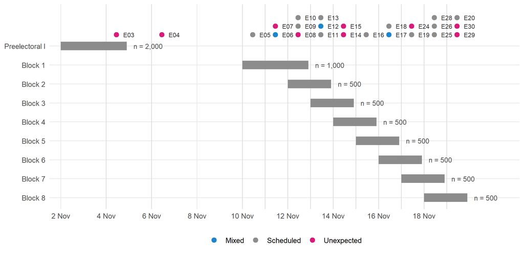

Figure 3: Fieldwork blocks and events. Each bar is an independent sample block; points mark events by whether they were unexpected, scheduled or mixed (see Table 1).

40dB uses quotas for sex by age, autonomous community, municipality size and social class. We weighted each block separately by raking to the same population margins, taken from the weighted day-4 file, so that comparisons across days do not depend on which file an interview comes from. The weights are only mildly dispersed (design effects between 1.02 and 1.07).

We found 291 tracking interviews that are exact copies of another one on all 31 variables (exact age, province, ten propensities to vote…), almost always on a different fieldwork day. Their share grows over time, from 1.8% of block 1 to between 7% and 10% of each block from block 3 onwards. They are probably duplicated records or re-interviewed panellists. We keep them in the main analysis and drop them in a robustness check.

### 2.2 Design

We follow the Unexpected Event during Surveys Design (UESD, Muñoz et al. 2020), which compares respondents interviewed before and after an event. The causal interpretation rests on two assumptions. The first is **excludability**: the timing of the interview affects the outcome only through the event. In a campaign this is demanding, because there are several events every day, each triggers reactions (collateral events), and the vote may follow trends of its own. The second is **temporal ignorability**: the day of the interview must be independent of the potential outcomes. The tracking helps here, because each block is a fresh, complete quota sample, similar to a rolling cross-section (Johnston and Brady 2002), but in an online panel those who respond on one day could differ from those who respond on another.

Most campaign events are not unexpected in the strict UESD sense: debates, the campaign launch and manifestos were announced in advance, and their effects could be anticipated. We classify each event as unexpected, scheduled or mixed (Table 1).

For each event day, a block is *pre* if it ended before that day and *post* if it started after it. Blocks containing the event day are excluded from the main estimate. Events on the same day are estimated jointly as an **event day**. The estimates are intention-to-treat (ITT) effects: we do not know who learned about each event, and the tracking has no most-important-problem question that would allow an indirect check of exposure.

The main model is a weighted linear regression of each indicator on a *post* indicator, with HC2 standard errors and controls for the quota variables and education, all of them pre-treatment. Recalled 2023 vote is not included: it tends to drift towards current preference, so an event can shift it, which would introduce post-treatment bias (Montgomery et al. 2018). We use it as a control in an alternative specification and as a placebo outcome. Up to 12 November there is no tracking block entirely before the events, and the *pre* group is the pre-election survey; these comparisons, across different surveys and with intervening events, are weaker. The *q*-values adjust for multiple comparisons within each specification (Benjamini and Hochberg 1995).

### 2.3 Events

Table 1: Events during fieldwork and comparison blocks. * Approximate date. The full list, with descriptions and sources, is in events/events_29N.csv.

| ID | Date | Event | Type | Blocks before | Blocks after |
| --- | --- | --- | --- | --- | --- |
| E03 | 4 Nov* | Transport minister Puente resigns | Unexpected | — | 1, 2, 3, 4, 5, 6, 7, 8 |
| E04 | 6 Nov | Zapatero remains under investigation (Plus Ultra) | Unexpected | 0 | 1, 2, 3, 4, 5, 6, 7, 8 |
| E05 | 10 Nov | PP programme | Scheduled | 0 | 2, 3, 4, 5, 6, 7, 8 |
| E06 | 11 Nov | General strike on housing and police charges | Mixed | 0 | 2, 3, 4, 5, 6, 7, 8 |
| E07 | 11 Nov | Zapatero investigation extended | Unexpected | 0 | 2, 3, 4, 5, 6, 7, 8 |
| E08 | 12 Nov | Marlaska opens an inquiry; Sánchez backs him | Unexpected | 0 | 3, 4, 5, 6, 7, 8 |
| E09 | 12 Nov | Vote on the housing decrees | Scheduled | 0 | 3, 4, 5, 6, 7, 8 |
| E10 | 12 Nov | CIS macro-survey | Scheduled | 0 | 3, 4, 5, 6, 7, 8 |
| E11 | 13 Nov | Official campaign start; Vox programme | Scheduled | 0, 1 | 4, 5, 6, 7, 8 |
| E12 | 13 Nov | Jordi Wild interviews; Abascal pulls out | Mixed | 0, 1 | 4, 5, 6, 7, 8 |
| E13 | 13 Nov* | Economic debate on laSexta | Scheduled | 0, 1 | 4, 5, 6, 7, 8 |
| E14 | 14 Nov* | Attack on a PP event in Hernani | Unexpected | 0, 1, 2 | 5, 6, 7, 8 |
| E15 | 14 Nov* | Record boat arrivals in the Canary Islands | Unexpected | 0, 1, 2 | 5, 6, 7, 8 |
| E16 | 15 Nov | PSOE programme; Sánchez calls Abascal ‘racist’ | Scheduled | 0, 1, 2, 3 | 6, 7, 8 |
| E17 | 16 Nov | Lula at Moncloa; Frente Amplio programme; CNI report on Ceuta | Mixed | 0, 1, 2, 3, 4 | 7, 8 |
| E18 | 16 Nov* | Sánchez interview on Telecinco (Ceuta) | Scheduled | 0, 1, 2, 3, 4 | 7, 8 |
| E19 | 17 Nov | Public-sector pay and minimum wage rises | Scheduled | 0, 1, 2, 3, 4, 5 | 8 |
| E24 | 17 Nov | Abascal’s wife receives a heating subsidy | Unexpected | 0, 1, 2, 3, 4, 5 | 8 |
| E25 | 18 Nov | Feijóo interview on the podcast El sentido de la birra | Scheduled | 0, 1, 2, 3, 4, 5, 6 | — |
| E26 | 18 Nov | Sánchez interview on Antena 3 | Scheduled | 0, 1, 2, 3, 4, 5, 6 | — |
| E28 | 18 Nov | Diputación Permanente validates seven decree-laws | Scheduled | 0, 1, 2, 3, 4, 5, 6 | — |
| E29 | 19 Nov | Puigdemont interview in El Mundo | Unexpected | 0, 1, 2, 3, 4, 5, 6, 7 | — |
| E30 | 19 Nov | Police report: the Ceuta mass entry was planned | Unexpected | 0, 1, 2, 3, 4, 5, 6, 7 | — |
| E20 | 19 Nov | Sánchez–Feijóo head-to-head debate | Scheduled | 0, 1, 2, 3, 4, 5, 6, 7 | — |

10 and 11 November share comparison groups and have identical estimates. Events on 18 and 19 November do not yet have any later block.

### 2.4 Diagnostics

Table 2: Diagnostics by event day. Joint balance: Wald test of non-quota covariates and recalled vote as predictors of being interviewed after the event. Refusals and DK: post − pre difference in points (p-value). Power: probability of detecting a 5-point effect on Vox vote intention.

| Day | Pre group | n pre/post | Joint balance | Placebos p<0.05 | Refuses vote intention | DK turnout | Power (5 pts) |
| --- | --- | --- | --- | --- | --- | --- | --- |
| 11 Nov E06, E07 | Preelectoral I | 2000/3500 | χ²(17) = 18.0, p = 0.392 | 0/5 | −0.4 (0.28) | −0.1 (0.84) | 1.00 |
| 12 Nov E08, E09, E10 | Preelectoral I | 2000/3000 | χ²(17) = 20.4, p = 0.254 | 1/5 | −0.3 (0.42) | 0.0 (0.91) | 0.99 |
| 13 Nov E11, E12, E13 | Tracking | 1000/2500 | χ²(17) = 19.8, p = 0.285 | 0/5 | −0.7 (0.19) | +0.6 (0.17) | 0.92 |
| 14 Nov E14, E15 | Tracking | 1500/2000 | χ²(17) = 23.7, p = 0.129 | 1/5 | −0.2 (0.63) | +0.7 (0.10) | 0.96 |
| 15 Nov E16 | Tracking | 2000/1500 | χ²(17) = 25.2, p = 0.091 | 0/5 | 0.0 (0.94) | +0.2 (0.55) | 0.97 |
| 16 Nov E17, E18 | Tracking | 2500/1000 | χ²(17) = 18.7, p = 0.343 | 0/5 | 0.0 (0.93) | 0.0 (0.99) | 0.93 |
| 17 Nov E19, E24 | Tracking | 3000/500 | χ²(17) = 16.2, p = 0.507 | 0/5 | +0.2 (0.82) | −0.4 (0.45) | 0.78 |

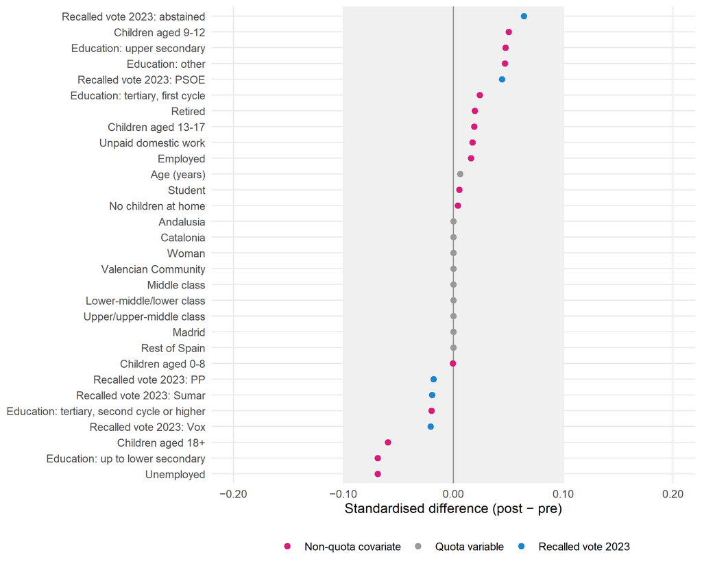

Figure 4: Covariate balance between the pre (block 1) and post (blocks 4 to 8) groups for 13 November. The grey band marks standardised differences below 0.1.

**Item non-response.** The share refusing to state a vote intention is stable. The share who do not know whether they will vote rises slightly after 13 and 14 November (from about 1% to about 2%), but the difference is not significant.

**Pre-period stability.** The placebo test of splitting the control group at the median day is not possible, because block 1 has no individual dates. Instead, we compare block 1 with the pre-election survey: the difference for Vox is +2.1 points (p = 0.171), not significant but in the direction that could inflate the later fall.

**Power.** The minimum detectable effect at 80% power for Vox vote intention is 4.1 points for 13 November and 3.7 for 14 November. No omnibus test of differences across the 8 tracking blocks survives the multiple-comparison adjustment (minimum *q* = 0.75; unadjusted, Vox p = 0.042 and Abascal as best prime minister p = 0.077).

### 2.5 Detailed results

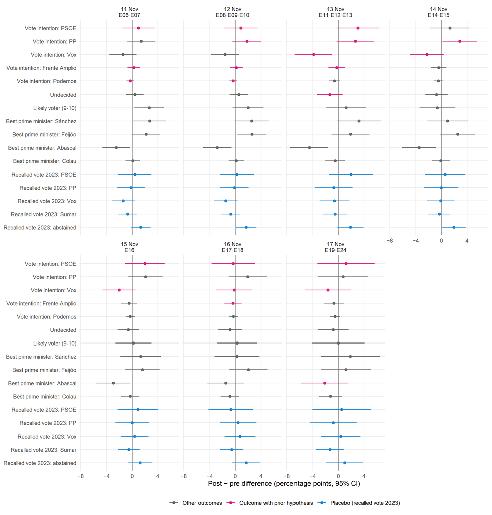

Figure 5: Post − pre differences by event day (main specification). For 11 and 12 November the pre group is the pre-election survey; from 13 November on, the tracking blocks before the event. Magenta: indicators with a prior hypothesis; blue: placebos.

Table 3: 13 November: differences between respondents interviewed on 14–19 and on 10–12 November. Pre: percentage in block 1. Weighted linear regression with quota and education controls; HC2 errors; q: Benjamini-Hochberg values.

| Indicator | Pre (%) | Difference (points) | 95% CI | p | q |
| --- | --- | --- | --- | --- | --- |
| Vote intention: PSOE | 26.6 | +3.1 | [−0.3; 6.4] | 0.071 | 0.55 |
| Vote intention: PP | 19.9 | +2.7 | [−0.3; 5.6] | 0.074 | 0.55 |
| Vote intention: Vox | 20.0 | −3.9 | [−6.8; −1.0] | 0.009 | 0.26 |
| Vote intention: Frente Amplio | 3.3 | −0.3 | [−1.6; 1.1] | 0.702 | 0.85 |
| Vote intention: Podemos | 1.6 | −0.6 | [−1.5; 0.3] | 0.163 | 0.64 |
| Undecided | 8.5 | −1.3 | [−3.4; 0.7] | 0.189 | 0.64 |
| Likely voter (9-10) | 75.8 | +1.2 | [−1.9; 4.3] | 0.446 | 0.74 |
| Best prime minister: Sánchez | 29.3 | +3.2 | [−0.2; 6.6] | 0.065 | 0.55 |
| Best prime minister: Feijóo | 21.0 | +1.9 | [−1.1; 4.8] | 0.211 | 0.64 |
| Best prime minister: Abascal | 21.1 | −4.5 | [−7.5; −1.6] | 0.002 | 0.18 |
| Best prime minister: Colau | 4.8 | −0.5 | [−2.0; 1.1] | 0.533 | 0.78 |

The falls for Abascal as best prime minister (−4.5 points (p = 0.002; q = 0.18)) and for Vox (−3.9 points (p = 0.009; q = 0.26)) have the lowest *q*-values on 13 November, but with 75 tests in the main specification neither falls below 0.1. The estimate for the PSOE is +3.1 points (p = 0.071; q = 0.55) and for the PP +2.7 points (p = 0.074; q = 0.55). The falls for Vox and Abascal are significant in all 8 specifications in Figure 6. When blocks containing 13 November are treated as post, the effect on Vox shrinks to −3.5 points (p = 0.013), and with the pre-election survey added to the *pre* group it is −2.5 points (p = 0.017). The PP’s gain is significant in 2 of the 8 specifications, and the PSOE’s in 2.

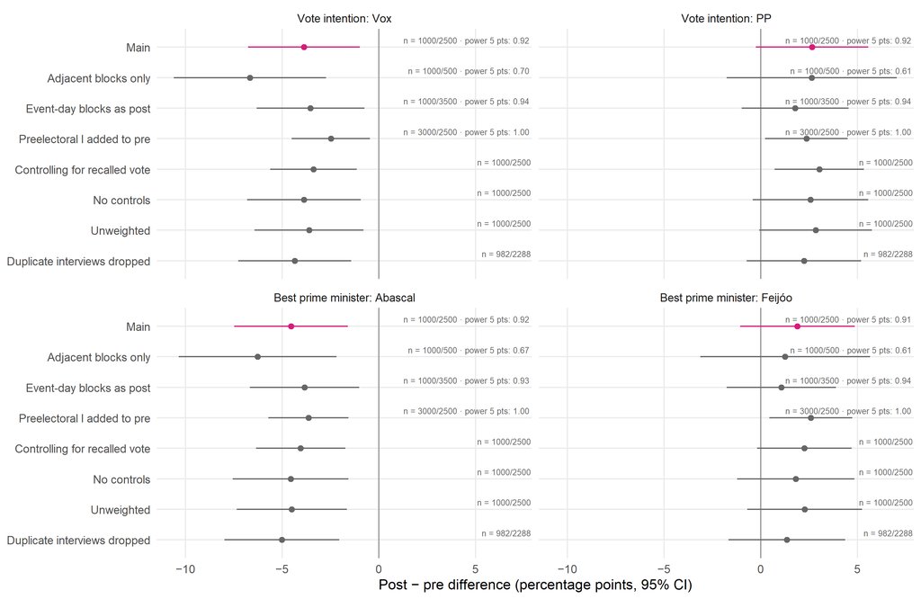

Figure 6: Robustness of the 13 November estimates. For each specification the label shows the pre/post group sizes and, for window variations, the power to detect a 5-point effect.

**Heterogeneity.** Figure 7 shows effects in groups defined before estimation. Among men aged 18 to 34, the difference in Vox vote intention on 13 November is −6.7 points (p = 0.211) (103 respondents pre and 250 post), concentrated mostly in block 4. Among 2023 PSOE and Sumar voters, the difference in Frente Amplio vote intention after the strike is +0.6 points (p = 0.559) and in PSOE vote intention +1.7 points (p = 0.430). For 14 November, the difference for the PP is +2.8 points (p = 0.037), but the *pre* group includes blocks before 13 November and inherits that day’s trend, a violation of excludability through a time trend (Muñoz et al. 2020). The regional falsification tests (H4 and H5) have only 122 and 88 cases in the post group. Heterogeneity by recalled vote (H1, H3) and the vote flows should be read with caution, because the moderator could be affected by the treatment.

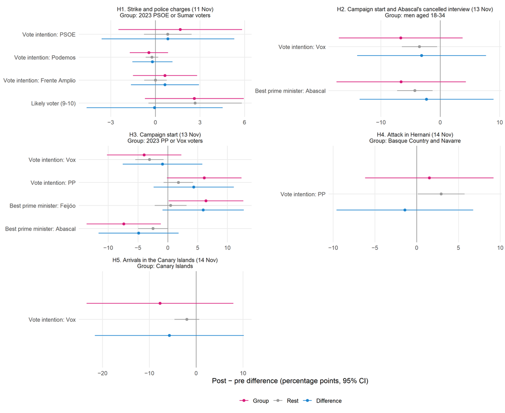

Figure 7: Effects in groups defined in advance. Group: post − pre difference within the group; Rest: outside the group; Difference: interaction.

## References

40dB. 2026a. *Encuesta preelectoral I, noviembre de 2026*. Microdatos, cuestionario, nota metodológica, tablas e informe. Encuesta para El País y la Cadena SER. https://ep00.epimg.net/infografias/encuestas40db/2026/11-preelectoral/2026_11_preelectoral_descargables.zip.

40dB. 2026b. *Tracking electoral 29-N, días 2 a 5*. Microdatos, cuestionarios, notas metodológicas, tablas e informes diarios (40dB_tracking_dia02.zip a dia05.zip). Encuesta para El País y la Cadena SER. https://ep00.epimg.net/infografias/encuestas40db/2026/11-tracking-electoral/40dB_tracking_dia05.zip.

Benjamini, Yoav, and Yosef Hochberg. 1995. ‘Controlling the False Discovery Rate: A Practical and Powerful Approach to Multiple Testing’. *Journal of the Royal Statistical Society: Series B (Methodological)* 57 (1): 289–300. https://doi.org/10.1111/j.2517-6161.1995.tb02031.x.

El País. 2026. ‘Vox se frena y cede terreno al PP’. *El País*, November 17. https://elpais.com/espana/elecciones-generales/2026-11-17/vox-se-frena-y-cede-terreno-al-pp.html.

Johnston, Richard, and Henry E. Brady. 2002. ‘The Rolling Cross-Section Design’. *Electoral Studies* 21 (2): 283–95. https://doi.org/10.1016/S0261-3794(01)00022-1.

Montgomery, Jacob M., Brendan Nyhan, and Michelle Torres. 2018. ‘How Conditioning on Posttreatment Variables Can Ruin Your Experiment and What to Do about It’. *American Journal of Political Science* 62 (3): 760–75. https://doi.org/10.1111/ajps.12357.

Muñoz, Jordi, Albert Falcó-Gimeno, and Enrique Hernández. 2020. ‘Unexpected Event During Survey Design: Promise and Pitfalls for Causal Inference’. *Political Analysis* 28 (2): 186–206. https://doi.org/10.1017/pan.2019.27.

Shaw, Daron R. 1999. ‘A Study of Presidential Campaign Event Effects from 1952 to 1992’. *The Journal of Politics* 61 (2): 387–422. https://doi.org/10.2307/2647509.